# Exercise 4: Plotting with ggplot2 + other useful packages

```r
library(readr)
library(dplyr)
library(RColorBrewer)
library(ComplexHeatmap)
library(ggplot2)
```

# Question 1

For this question, we will continue to use the *gapminder* dataset:

```r
gapminder <- read_csv(file = "../data/gapminder-FiveYearData.csv")
```

Try to replicate the following plots. You will have to explore other options within the `geoms` and other elements like `theme`. Guide yourself with the material [here](http://ggplot2.tidyverse.org/reference/).

**Optional:** What plot would YOU make to visualise this dataset?

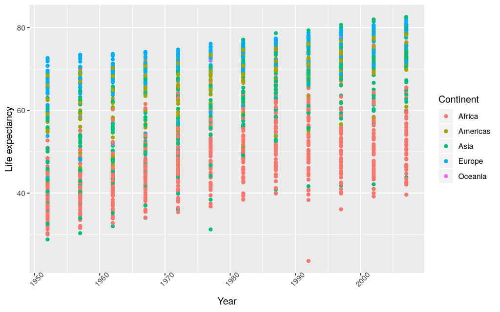

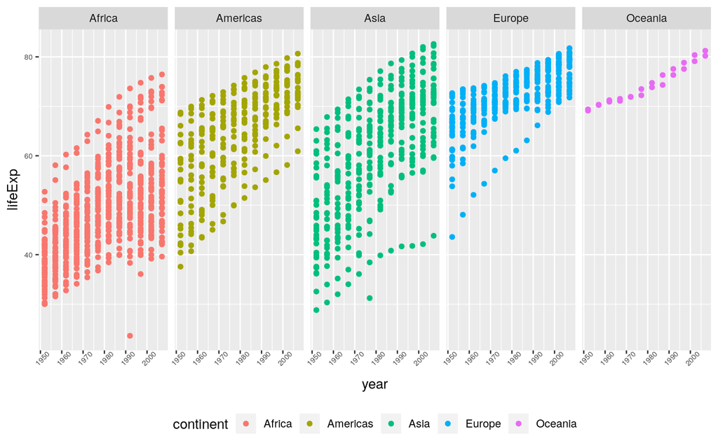

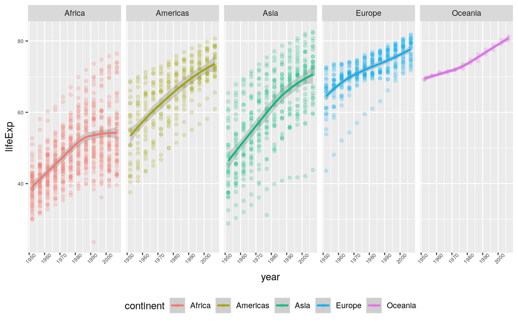

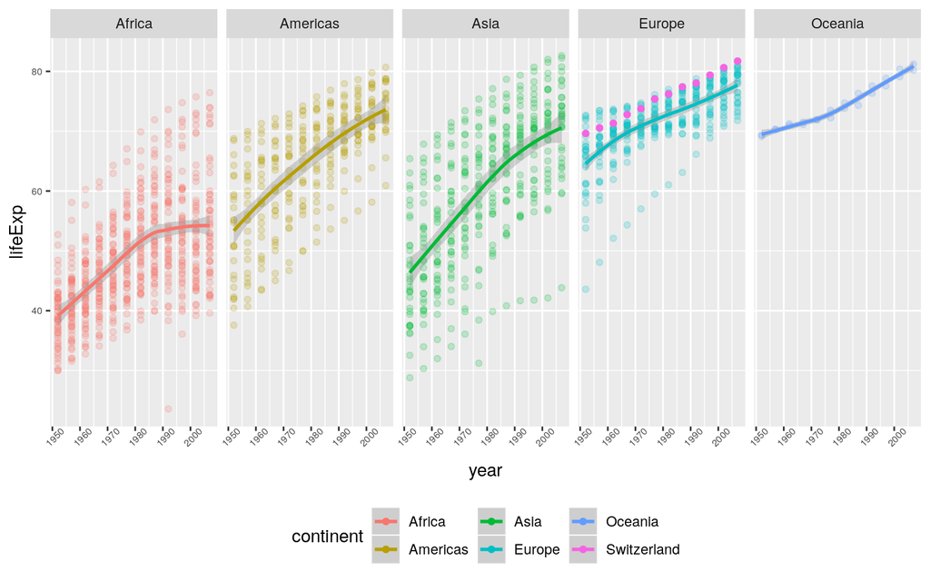

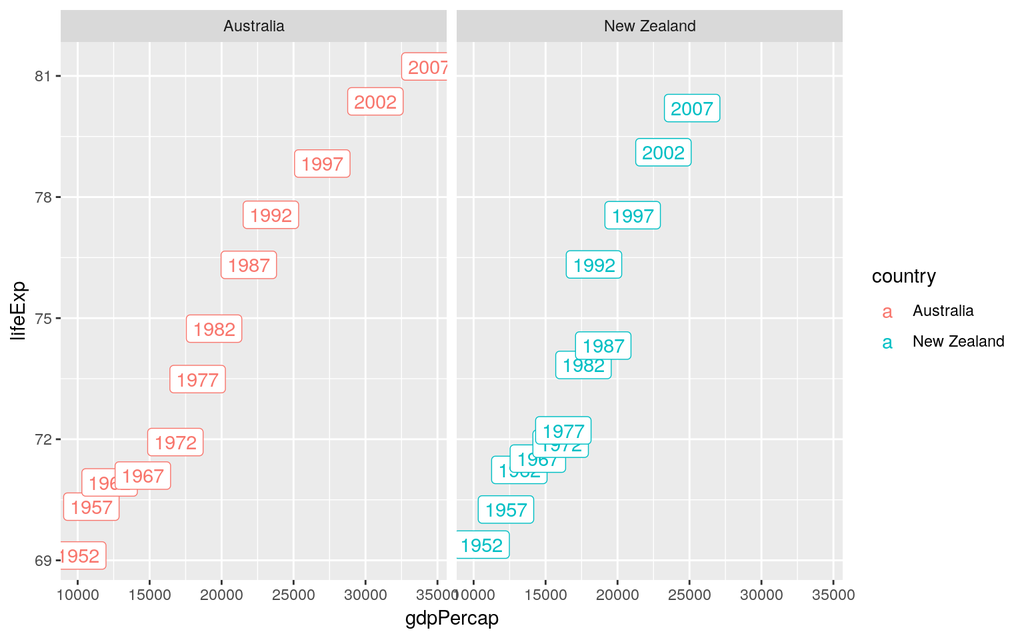

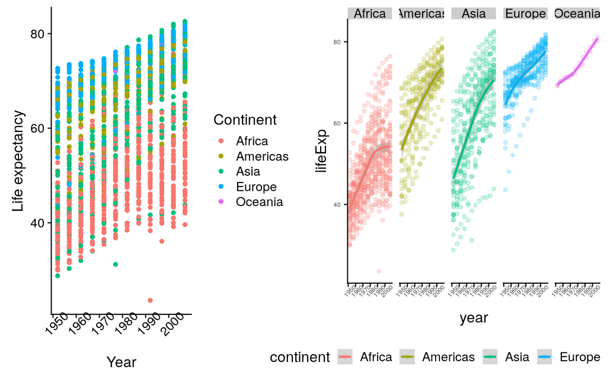

# Question 2

For this part, you will create the **Heatmap** using the `airway` dataset from Exercise 3 (on Friday).

First load the data, which is ready for plotting (you DO NOT have to do anything to it!)

```r
load("../data/airway_subset.RData")
```

This is the code we used to generate the data. We show it here in case you are interested.

```r
# library(airway)
# library(edgeR)
# data("airway")
#
# sample_info <- airway %>%
#     colData %>%
#     as.data.frame %>%
#     rename(group = dex) %>%
#     rename(sample = Run) %>%
#     select(sample, group)
#
# # select a subset of data
# expr <- assay(airway)
# dge <- DGEList(counts = expr, samples = sample_info)
# dge <- calcNormFactors(dge, method = "TMM")
# dge <- estimateDisp(dge)
# fit <- glmFit(dge)
# results <- glmLRT(fit, coef=2)
# diffG <- rownames(topTags(results, n = 5))
# set.seed(1)
# sameG <- sample(setdiff(rownames(expr), diffG), 15)
#
# sel <- sample(c(diffG, sameG))
# gene_counts  <- expr[sel, ]
#
# save(gene_counts, sample_info, file = "../data/airway_subset.RData")
```

We will use two tables: `sample_info` and `gene_counts`. Make sure you take a look at them before starting.

1. How many samples are in the `gene_counts`? How many genes are measured? How many samples are measured in each group?
2. Create a simple heatmap to visualize the data.
3. Improve the heatmap. For example, adjust the size of the gene names, annotate the samples, hide the column dendogram, or use other colors…(Use a nice color palette from [brewer.pal](https://moderndata.plot.ly/create-colorful-graphs-in-r-with-rcolorbrewer-and-plotly/))
4. Do you see difference between groups from the heatmap? Provide at least one gene that has different levels between groups.
5. **Optional:** Make boxplots for each gene on the left of the heatmap. [Help here](https://jokergoo.github.io/ComplexHeatmap-reference/book/heatmap-annotations.html#box-annotation)

If you want to play around more, you can look for [more ideas](https://jokergoo.github.io/ComplexHeatmap-reference/book/more-examples.html), and customize your Heatmap until you are happy with it.